# Q4

Mihir Deshpande

2022-08-14

## Visual story telling part 2: Capital Metro data

The file capmetro_UT.csv contains data from Austin’s own Capital Metro bus network, including shuttles to, from, and around the UT campus. These data track ridership on buses in the UT area. Ridership is measured by an optical scanner that counts how many people embark and alight the bus at each stop. Each row in the data set corresponds to a 15-minute period between the hours of 6 AM and 10 PM, each and every day, from September through November 2018. The variables are:

- *timestamp*: the beginning of the 15-minute window for that row of data
- *boarding*: how many people got on board any Capital Metro bus on the UT campus in the specific 15 minute window
- *alighting*: how many people got off (“alit”) any Capital Metro bus on the UT campus in the specific 15 minute window
- *day_of_week* and *weekend*: Monday, Tuesday, etc, as well as an indicator for whether it’s a weekend.
- *temperature*: temperature at that time in degrees F
- *hour_of_day*: on 24-hour time, so 6 for 6 AM, 13 for 1 PM, 14 for 2 PM, etc.
- *month*: July through December

Your task is to create a figure, or set of related figures, that tell an interesting story about Capital Metro ridership patterns around the UT-Austin campus during the semester in question. Provide a clear annotation/caption for each figure, but the figure(s) should be more or less stand-alone, in that you shouldn’t need many, many paragraphs to convey its meaning. Rather, the figure together with a concise caption should speak for itself as far as possible.

You have broad freedom to look at any variables you’d like here – try to find that sweet spot where you’re showing genuinely interesting relationships among more than just two variables, but where the resulting figure or set of figures doesn’t become overwhelming/confusing. (Faceting/panel plots might be especially useful here.)

### Solution:

```
##   timestamp            boarding        alighting      day_of_week
##  Length:5824        Min.   :  0.00   Min.   :  0.00   Length:5824
##  Class :character   1st Qu.: 13.00   1st Qu.: 13.00   Class :character
##  Mode  :character   Median : 33.00   Median : 28.00   Mode  :character
##                     Mean   : 51.51   Mean   : 47.65
##                     3rd Qu.: 79.25   3rd Qu.: 64.00
##                     Max.   :288.00   Max.   :304.00
##   temperature     hour_of_day       month             weekend
##  Min.   :29.18   Min.   : 6.00   Length:5824        Length:5824
##  1st Qu.:59.20   1st Qu.: 9.75   Class :character   Class :character
##  Median :72.75   Median :13.50   Mode  :character   Mode  :character
##  Mean   :69.28   Mean   :13.50
##  3rd Qu.:79.29   3rd Qu.:17.25
##  Max.   :97.64   Max.   :21.00
```

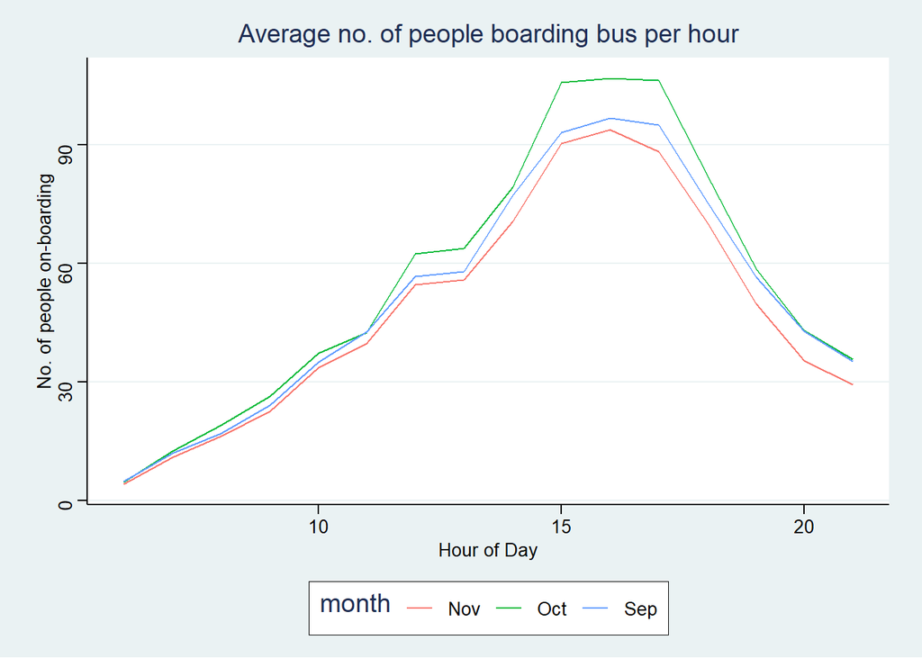

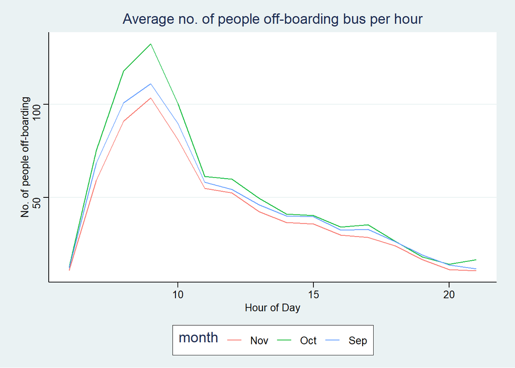

There are some weird discrepancies if you look at it without thinking much.

This distribution seems to be heavily influenced by students going to and fro from campus for college. Let’s try to look at the distribution on the weekends -

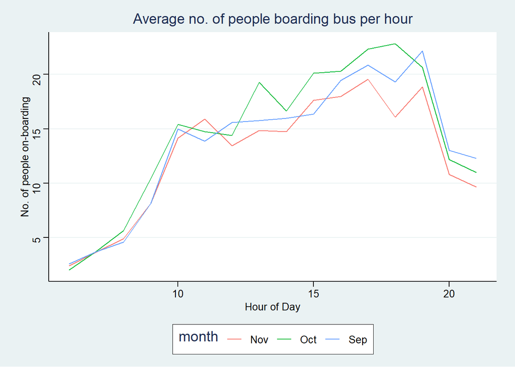

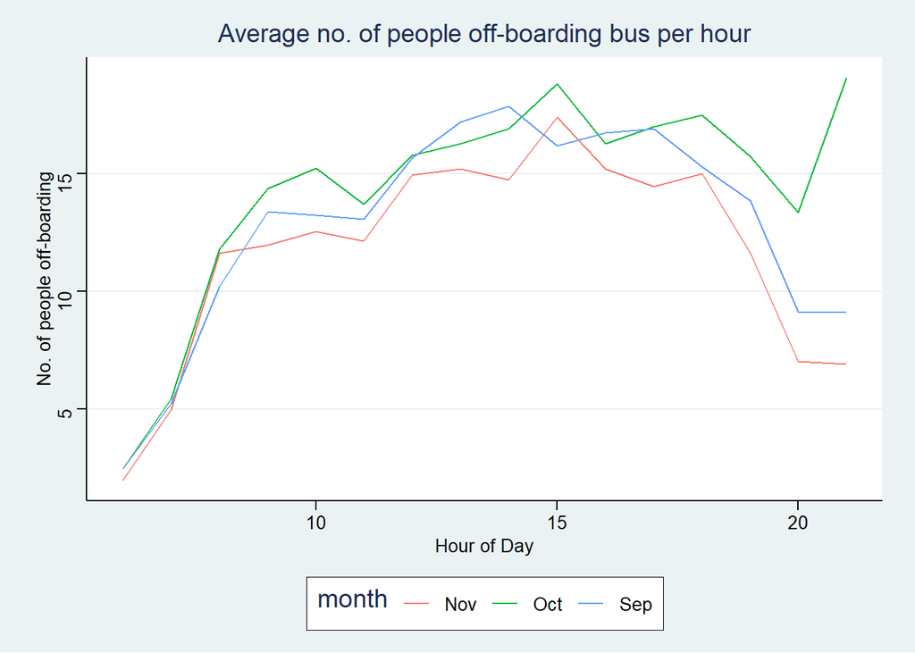

- The counts are much more varying throughout the day now
- There is an interesting spike in no. of off-boarding people in October towards the end of the day. Maybe this is because October is when students have their mid-terms for the semester so they tend to stay late on campus and go home during late hours of the day.

Let’s also look at how weekend ridership changes based on temperature (since the weekday ridership is expected to not be affected by temperature since students have to go to college regardless) -

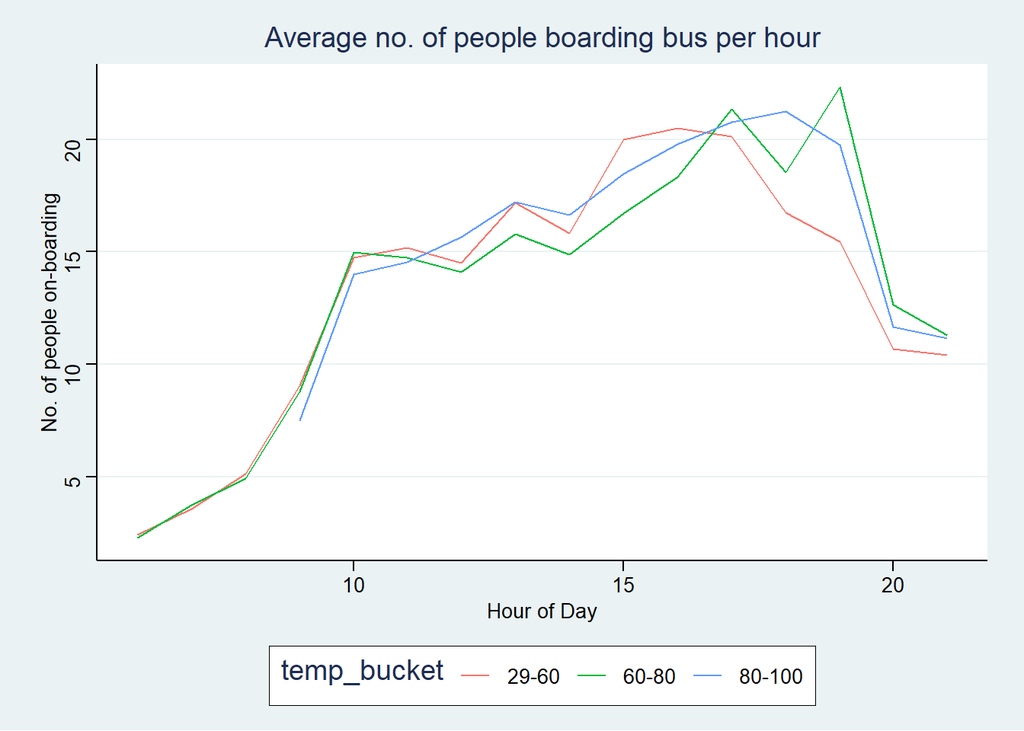

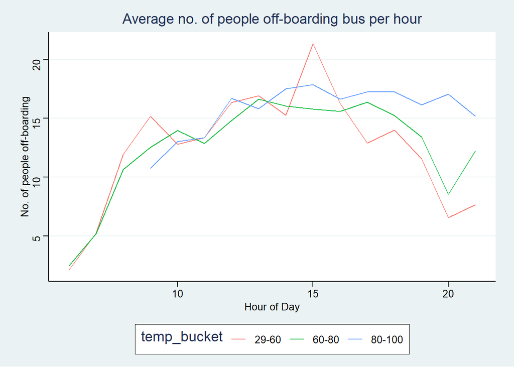

- The temperature doesn’t seem to affect ridership during the weekend so much since the patterns and numbers match those when we don’t account for temperature separately. We’ve got some pretty interesting insights from these graphs!

Finally, let’s look at the difference in total on-boardings and off-boardings per day -

```
## geom_path: Each group consists of only one observation. Do you need to adjust
## the group aesthetic?
```

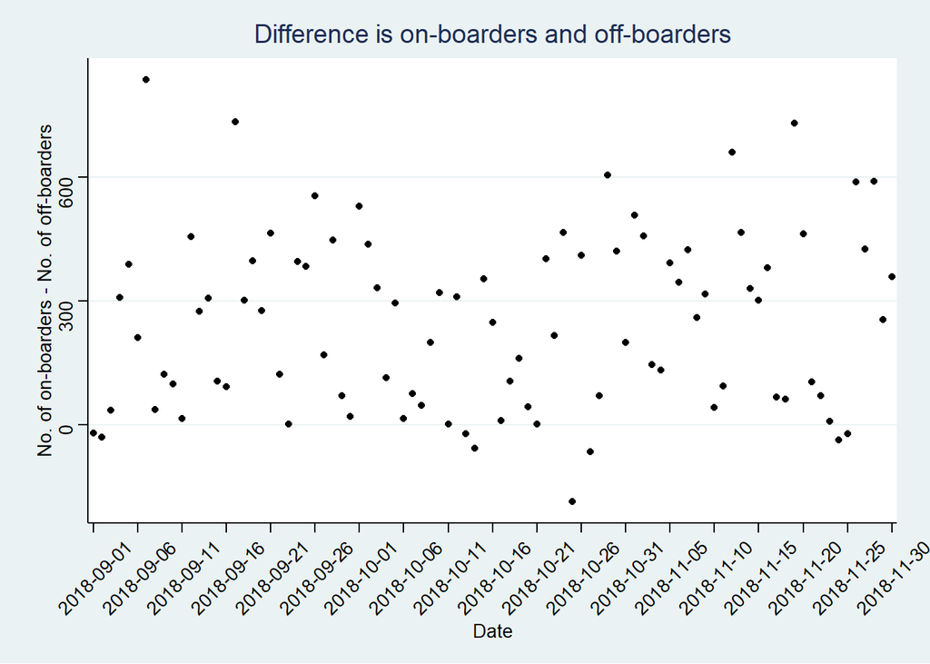